# Species Accumulation CurvesArtenakkumulationskurven

How do we count species we can’t see?Wie zählt man Arten, die man nicht sieht?

Ecology Practicum - Day 1Ökologie-Praktikum - Tag 1

2026-01-20

# Part 1: The Big QuestionTeil 1: Die große Frage

## What is Biodiversity?Was ist Biodiversität?

**Biodiversity** = the variety of life in an area

Think of it like this: If you visited two forests…

| Forest A | Forest B |
| --- | --- |
| Oak, Oak, Oak, Oak, Oak | Oak, Beech, Maple, Pine, Birch |
| 5 trees, **1 species** | 5 trees, **5 species** |

**Which forest is more biodiverse?** Forest B - even though both have the same number of trees.

**Biodiversität** = die Vielfalt des Lebens in einem Gebiet

Denk an zwei Wälder…

| Wald A | Wald B |
| --- | --- |
| Eiche, Eiche, Eiche, Eiche, Eiche | Eiche, Buche, Ahorn, Kiefer, Birke |
| 5 Bäume, **1 Art** | 5 Bäume, **5 Arten** |

**Welcher Wald ist artenreicher?** Wald B - obwohl beide gleich viele Bäume haben.

## Why Does Biodiversity Matter?Warum ist Biodiversität wichtig?

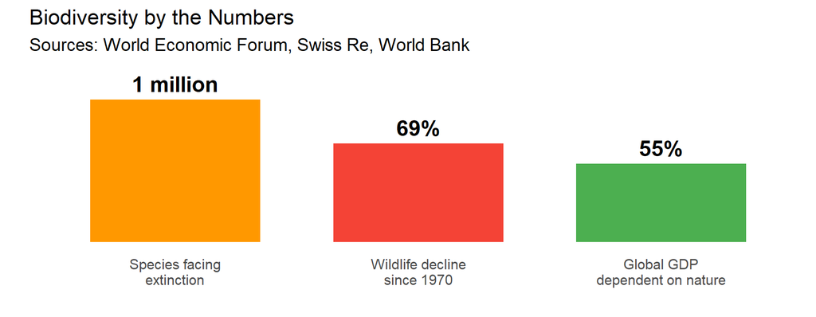

- **55% of global GDP** ($44 trillion) depends on healthy ecosystems
- **69% decline** in wildlife populations since 1970
- **1 million species** face extinction in coming decades
- Ecosystem services worth **$150+ trillion/year** (1.5x global GDP)

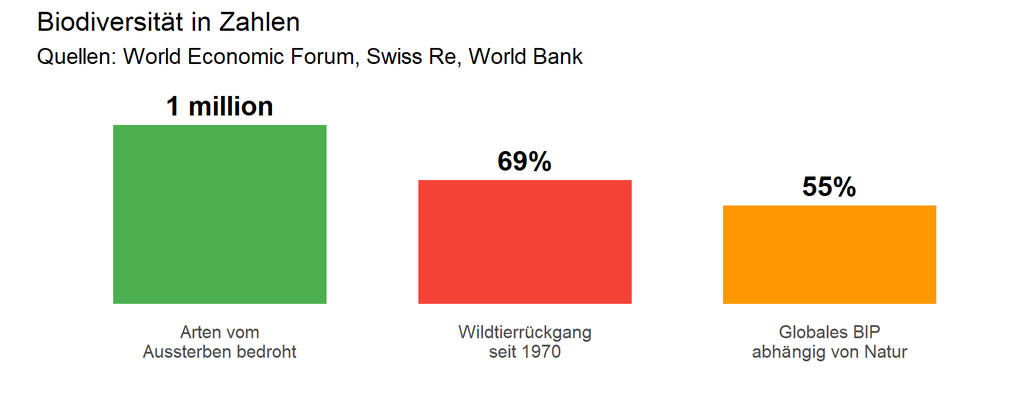

- **55% des globalen BIP** ($44 Billionen) hängt von gesunden Ökosystemen ab
- **69% Rückgang** der Wildtierpopulationen seit 1970
- **1 Million Arten** vom Aussterben bedroht
- Ökosystemleistungen wert **$150+ Billionen/Jahr** (1,5x globales BIP)

## The Counting ProblemDas Zählproblem

**Question:** How many plant species are in Austria?

**Answer:** About **3,500** native plant species

**But how do we know this?**

We can’t walk across all of Austria and count every plant. That would take… forever.

**Frage:** Wie viele Pflanzenarten gibt es in Österreich?

**Antwort:** Etwa **3.500** heimische Pflanzenarten

**Aber wie wissen wir das?**

Wir können nicht durch ganz Österreich wandern und jede Pflanze zählen. Das würde… ewig dauern.

## The Sampling SolutionDie Lösung: Stichproben

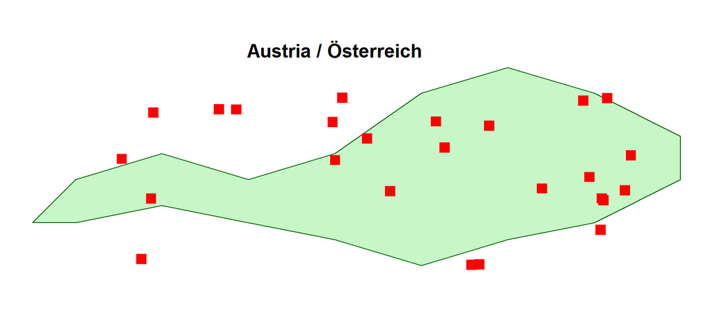

**Key insight:** We study small plots carefully, then use patterns to understand the whole.

Red squares = vegetation plots (samples)

**Kernidee:** Wir untersuchen kleine Flächen sorgfältig und nutzen Muster, um das Ganze zu verstehen.

Rote Quadrate = Vegetationsplots (Stichproben)

## Discussion Question 1Diskussionsfrage 1

Imagine you want to know how many different types of candy exist in a candy store.

You have **5 minutes** and can look in **10 jars** (out of 100 total jars).

**Which strategy is better?**

1. Look at the 10 jars closest to the door
2. Look at 10 jars spread throughout the store

**Why does this matter for ecology?**

Stell dir vor, du willst wissen, wie viele verschiedene Süßigkeiten es in einem Süßwarenladen gibt.

Du hast **5 Minuten** und kannst in **10 Gläser** schauen (von insgesamt 100).

**Welche Strategie ist besser?**

1. Die 10 Gläser direkt neben der Tür
2. 10 Gläser verteilt im ganzen Laden

**Warum ist das für Ökologie wichtig?**

# Part 2: Species Accumulation CurvesTeil 2: Artenakkumulationskurven

## The Core IdeaDie Kernidee

As we sample more and more plots, we discover more species.

But here’s the interesting part: **the rate of discovery slows down**.

Je mehr wir stichproben, desto mehr Arten entdecken wir.

Aber: **Die Entdeckungsrate verlangsamt sich.**

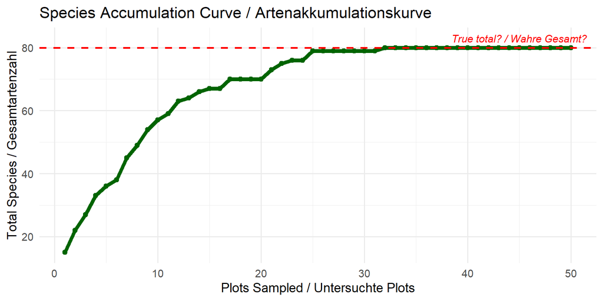

## Why Does the Curve Flatten?Warum flacht die Kurve ab?

Think of it like a **card game**:

| Draw # | What happens |
| --- | --- |
| 1st card | Definitely new! |
| 10th card | Probably still new |
| 30th card | Maybe seen it before |
| 50th card | Very likely a repeat |

**The more species you’ve already found, the harder it is to find new ones.**

Denk an ein **Kartenspiel**:

| Karte # | Was passiert |
| --- | --- |
| 1. Karte | Definitiv neu! |
| 10. Karte | Wahrscheinlich noch neu |
| 30. Karte | Vielleicht schon gesehen |
| 50. Karte | Sehr wahrscheinlich ein Duplikat |

**Je mehr Arten du schon gefunden hast, desto schwieriger wird es, neue zu finden.**

## Let’s Build One TogetherLasst uns eine Kurve bauen

Imagine we’re sampling a meadow. Each “plot” reveals some species:

| Plot | Species.Found | New.Species | Cumulative.Total |
| --- | --- | --- | --- |
| 1 | Daisy, Clover, Grass | 3 | 3 |
| 2 | Buttercup, Dandelion, Grass | 2 | 5 |
| 3 | Daisy, Thistle, Clover | 1 | 6 |
| 4 | Grass, Plantain, Daisy | 1 | 7 |
| 5 | Clover, Buttercup, Yarrow | 1 | 8 |
| 6 | Daisy, Grass, Clover | 0 | 8 |
| 7 | Dandelion, Plantain, Grass | 0 | 8 |
| 8 | Clover, Daisy, Sorrel | 1 | 9 |

**Notice:** By plot 6-7, we’re not finding anything new!

Stell dir vor, wir untersuchen eine Wiese. Jeder “Plot” zeigt einige Arten:

| Plot | Gefundene.Arten | Neue.Arten | Kumulativ |
| --- | --- | --- | --- |
| 1 | Gänseblümchen, Klee, Gras | 3 | 3 |
| 2 | Butterblume, Löwenzahn, Gras | 2 | 5 |
| 3 | Gänseblümchen, Distel, Klee | 1 | 6 |
| 4 | Gras, Spitzwegerich, Gänseblümchen | 1 | 7 |
| 5 | Klee, Butterblume, Schafgarbe | 1 | 8 |
| 6 | Gänseblümchen, Gras, Klee | 0 | 8 |
| 7 | Löwenzahn, Spitzwegerich, Gras | 0 | 8 |
| 8 | Klee, Gänseblümchen, Sauerampfer | 1 | 9 |

**Beachte:** Bei Plot 6-7 finden wir nichts Neues mehr!

## Visualizing Our ExampleUnsere Beispielkurve

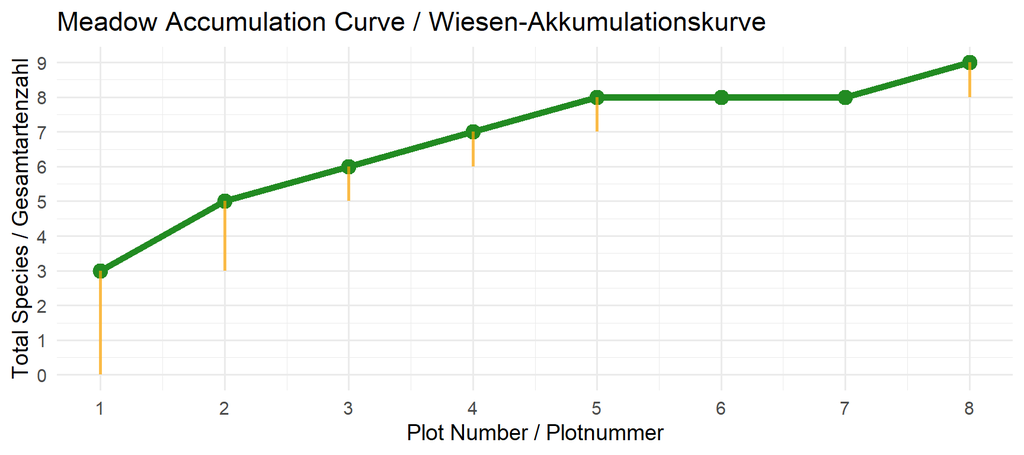

## Discussion Question 2Diskussionsfrage 2

Look at these two curves:

Schau dir diese zwei Kurven an:

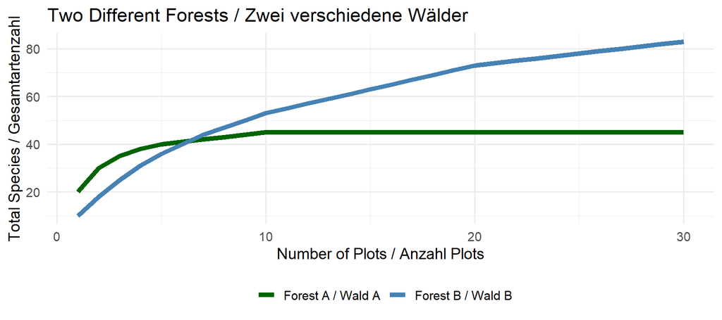

**Questions:**

1. Which forest probably has more total species?
2. Which forest has species spread more evenly?
3. In which forest would you need to sample MORE plots to find everything?

**Fragen:**

1. Welcher Wald hat wahrscheinlich mehr Arten insgesamt?
2. In welchem Wald sind die Arten gleichmäßiger verteilt?
3. In welchem Wald müsstest du MEHR Plots untersuchen, um alles zu finden?

## The Asymptote: Predicting the UnknowableDie Asymptote: Das Unbekannte vorhersagen

The **asymptote** is the line the curve approaches but never quite reaches.

It represents: **the estimated total number of species**

Die **Asymptote** ist die Linie, der sich die Kurve annähert, aber nie erreicht.

Sie repräsentiert: **die geschätzte Gesamtartenzahl**

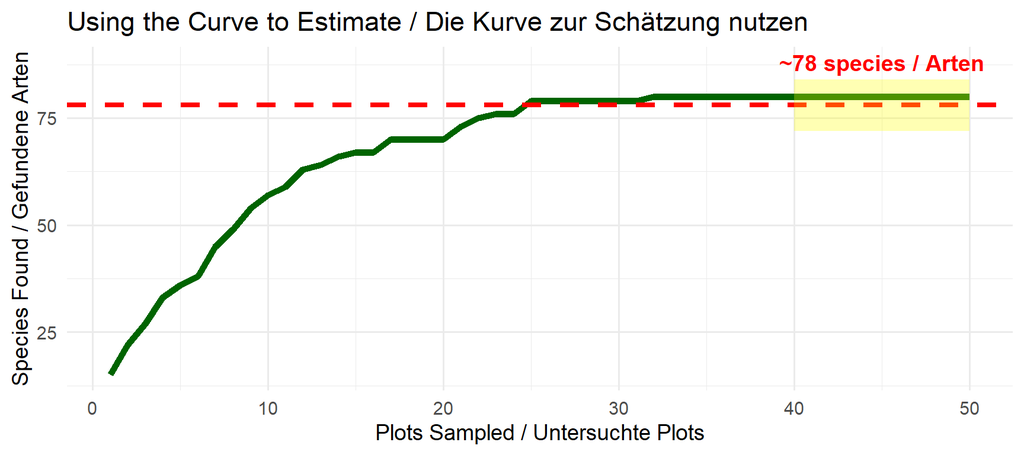

**Key insight:** Even without sampling EVERYTHING, we can estimate how much we’re missing!

**Kernidee:** Selbst ohne ALLES zu untersuchen, können wir schätzen, wie viel wir verpassen!

# Part 3: Vegetation Plots & Real DataTeil 3: Vegetationsplots & echte Daten

## What is a Vegetation Plot?Was ist ein Vegetationsplot?

A **vegetation plot** is a small area (usually 1-100 m²) where ecologists record every plant species present.

Ein **Vegetationsplot** ist eine kleine Fläche (meist 1-100 m²), auf der alle Pflanzenarten erfasst werden.

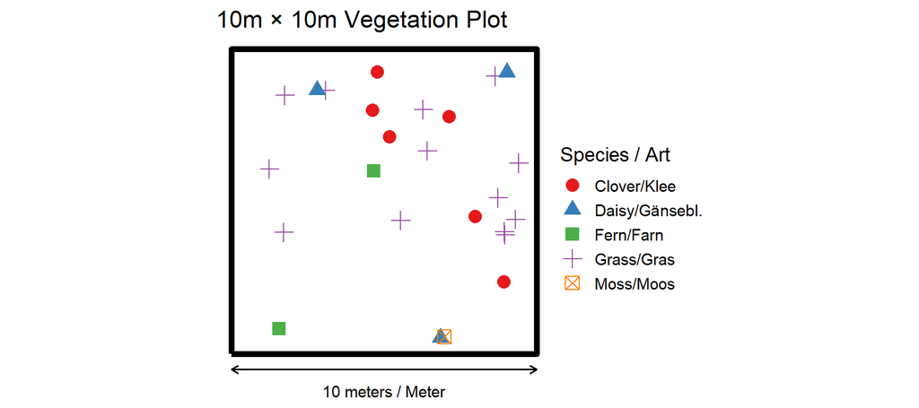

## What Gets Recorded?Was wird erfasst?

| Information | Example |
| --- | --- |
| **Location** | 47.5°N, 14.2°E (Austrian Alps) |
| **Date** | June 15, 2023 |
| **Habitat type** | Alpine meadow |
| **Altitude** | 1,850 m |
| **Species list** | Gentiana acaulis, Poa alpina, Trifolium pratense… |
| **Cover** | How much of the ground each species covers |

| Information | Beispiel |
| --- | --- |
| **Standort** | 47.5°N, 14.2°E (Österreichische Alpen) |
| **Datum** | 15. Juni 2023 |
| **Habitattyp** | Almwiese |
| **Höhe** | 1.850 m |
| **Artenliste** | Gentiana acaulis, Poa alpina, Trifolium pratense… |
| **Deckung** | Wie viel des Bodens jede Art bedeckt |

## Native vs. Alien SpeciesHeimische vs. Alien-Arten

| Native Species | Alien Species (Neophytes) |
| --- | --- |
| Evolved here over thousands of years | Arrived recently (after 1492) |
| Part of natural ecosystems | Introduced by humans |
| Example: Edelweiss | Example: Himalayan Balsam |

**Tomorrow’s question:** Do alien species spread across habitats differently than natives?

| Heimische Arten | Alien-Arten (Neophyten) |
| --- | --- |
| Hier seit Jahrtausenden | Kürzlich angekommen (nach 1492) |
| Teil natürlicher Ökosysteme | Von Menschen eingeführt |
| Beispiel: Edelweiß | Beispiel: Drüsiges Springkraut |

**Morgen:** Verbreiten sich Alien-Arten anders als heimische?

## Preview: Tomorrow’s InvestigationVorschau: Morgen

**Research Question:** Do alien plant species accumulate faster or slower than native species as we sample larger areas?

**Forschungsfrage:** Akkumulieren Alien-Pflanzenarten schneller oder langsamer als heimische Arten?

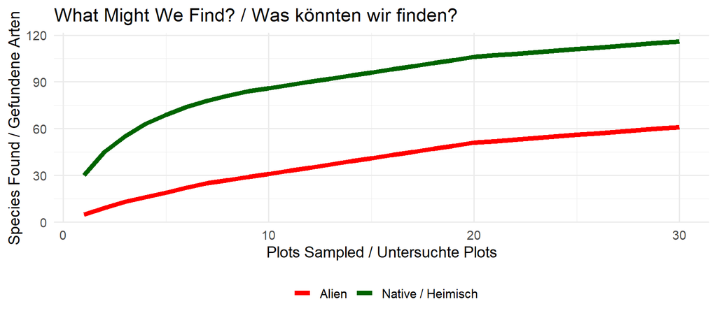

# Part 4: Introduction to RTeil 4: Einführung in R

## What is R?Was ist R?

**R** is a programming language for statistics and data analysis.

Why R?

- **Free** and Open Source
- **Reproducible** - anyone can follow your analysis
- **Powerful** - from simple calculations to complex models
- **Graphics** - professional visualizations

**R** ist eine Programmiersprache für Statistik und Datenanalyse.

Warum R?

- **Kostenlos** und Open Source
- **Reproduzierbar** - jeder kann deine Analyse nachvollziehen
- **Leistungsstark** - von einfachen Berechnungen bis komplexe Modelle
- **Grafiken** - professionelle Visualisierungen

## Getting to Know RStudioRStudio kennenlernen

RStudio is the **development environment** for R. Think of R as the engine, RStudio as the car around it.

### The Four Panels

RStudio has **4 main areas**:

| Area | Function | What you see there |
| --- | --- | --- |
| **Top left** | **Script Editor** | Your code that you can save and reuse |
| **Bottom left** | **Console** | Where commands run and results appear |
| **Top right** | **Environment** | All variables and objects you’ve created |
| **Bottom right** | **Files / Plots / Help** | File browser, graphics, package help |

### Running Code

**Create a new script:**

1. `File > New File > R Script` or `Ctrl + Shift + N`
2. Write your code
3. Save with `Ctrl + S`

**Run code:**

- **Ctrl + Enter** - runs the current line
- Select multiple lines → `Ctrl + Enter` - runs all selected

**Tip:** Always use scripts, not just the console! Then you can repeat your analysis later.

RStudio ist die **Entwicklungsumgebung** für R. Denk an R als Motor, RStudio als Auto drumherum.

### Die vier Bereiche

RStudio hat **4 Hauptbereiche**:

| Bereich | Funktion | Was siehst du dort? |
| --- | --- | --- |
| **Oben links** | **Skript-Editor** | Dein Code, den du speichern und wiederverwenden kannst |
| **Unten links** | **Konsole** | Hier werden Befehle ausgeführt und Ergebnisse angezeigt |
| **Oben rechts** | **Environment** | Alle Variablen und Objekte, die du erstellt hast |
| **Unten rechts** | **Dateien / Plots / Hilfe** | Dateibrowser, Grafiken, Paket-Hilfe |

### Code ausführen

**Neues Skript erstellen:**

1. `File > New File > R Script` oder `Ctrl + Shift + N`
2. Schreibe deinen Code
3. Speichern mit `Ctrl + S`

**Code ausführen:**

- **Ctrl + Enter** - führt die aktuelle Zeile aus
- Markiere mehrere Zeilen → `Ctrl + Enter` - führt alle aus

**Tipp:** Benutze immer Skripte, nicht nur die Konsole! Dann kannst du deine Analyse später wiederholen.

## Basic SyntaxGrundlegende Syntax

### VariablesVariablen

In R, we store values in **variables**:

```r
# With <- (preferred in R)
my_number <- 42
my_text <- "Hello World"

# Call a variable
my_number
```

**Rules for variable names:**

- Start with a letter (not numbers!)
- Can contain letters, numbers, `_` and `.`
- **Case-sensitive**: `Number` ≠ `number`

In R speichern wir Werte in **Variablen**:

```r
# Mit <- (bevorzugt in R)
meine_zahl <- 42
mein_text <- "Hallo Welt"

# Variable aufrufen
meine_zahl
```

**Regeln für Variablennamen:**

- Beginnen mit Buchstaben (nicht Zahlen!)
- Können Buchstaben, Zahlen, `_` und `.` enthalten
- **Groß-/Kleinschreibung** ist wichtig: `Zahl` ≠ `zahl`

### VectorsVektoren

A **vector** is a list of values of the same type.

```r
# Create vector with c() (c = combine)
numbers <- c(1, 2, 3, 4, 5)
species <- c("Oak", "Beech", "Pine")

# Create sequences
one_to_ten <- 1:10

# Length of a vector
length(numbers)  # 5

# Access elements (R starts at 1!)
species[1]       # "Oak"
species[2:3]     # "Beech" "Pine"
```

**Vectors are fundamental in R!** Almost everything in R is a vector.

Ein **Vektor** ist eine Liste von Werten des gleichen Typs.

```r
# Vektor mit c() erstellen (c = combine)
zahlen <- c(1, 2, 3, 4, 5)
arten <- c("Eiche", "Buche", "Kiefer")

# Sequenzen erstellen
eins_bis_zehn <- 1:10

# Länge eines Vektors
length(zahlen)  # 5

# Auf Elemente zugreifen (R beginnt bei 1!)
arten[1]        # "Eiche"
arten[2:3]      # "Buche" "Kiefer"
```

**Vektoren sind fundamental in R!** Fast alles in R ist ein Vektor.

### Useful FunctionsNützliche Funktionen

```r
values <- c(5, 12, 8, 15, 3, 20, 7)

# Statistics
mean(values)      # Mean: 10
sum(values)       # Sum: 70
min(values)       # Minimum: 3
max(values)       # Maximum: 20

# Sorting
sort(values)      # 3, 5, 7, 8, 12, 15, 20

# Unique values
species <- c("Oak", "Beech", "Oak", "Pine", "Beech")
unique(species)   # "Oak" "Beech" "Pine"
length(unique(species))  # 3
```

```r
werte <- c(5, 12, 8, 15, 3, 20, 7)

# Statistik
mean(werte)       # Mittelwert: 10
sum(werte)        # Summe: 70
min(werte)        # Minimum: 3
max(werte)        # Maximum: 20

# Sortieren
sort(werte)       # 3, 5, 7, 8, 12, 15, 20

# Einzigartige Werte
arten <- c("Eiche", "Buche", "Eiche", "Kiefer", "Buche")
unique(arten)     # "Eiche" "Buche" "Kiefer"
length(unique(arten))  # 3
```

## Loading DataDaten laden

Most ecological data comes as **CSV** files.

```r
# Load a CSV file
data <- read.csv("plants.csv")

# First 6 rows
head(data)

# Structure overview
str(data)

# Summary statistics
summary(data)

# Dimensions
nrow(data)        # Number of rows
ncol(data)        # Number of columns

# Column names
names(data)

# Access a column
data$species
mean(data$height)
```

Die meisten ökologischen Daten kommen als **CSV** Dateien.

```r
# CSV-Datei laden
daten <- read.csv("pflanzen.csv")

# Erste 6 Zeilen
head(daten)

# Strukturübersicht
str(daten)

# Zusammenfassung
summary(daten)

# Dimensionen
nrow(daten)       # Anzahl Zeilen
ncol(daten)       # Anzahl Spalten

# Spaltennamen
names(daten)

# Auf Spalte zugreifen
daten$species
mean(daten$height)
```

## Common ErrorsHäufige Fehler

| Error | Problem | Solution |
| --- | --- | --- |
| `object 'x' not found` | Variable doesn’t exist | Check spelling, case |
| `could not find function` | Typo in function name | Check spelling |
| `cannot open file` | File not found | Check path, use `getwd()` |
| Unexpected `NA` | Missing values | Use `na.rm = TRUE` |

**Getting help:**

```r
?mean           # Help for function
example(mean)   # Show examples
```

| Fehler | Problem | Lösung |
| --- | --- | --- |
| `object 'x' not found` | Variable existiert nicht | Schreibweise prüfen |
| `could not find function` | Tippfehler im Funktionsnamen | Schreibweise prüfen |
| `cannot open file` | Datei nicht gefunden | Pfad prüfen, `getwd()` |
| Unerwartetes `NA` | Fehlende Werte | `na.rm = TRUE` verwenden |

**Hilfe bekommen:**

```r
?mean           # Hilfe für Funktion
example(mean)   # Beispiele zeigen
```

# Part 5: Hands-On ActivityTeil 5: Praktische Übung

## Your Turn: Build a CurveDu bist dran: Baue eine Kurve

Open the file: `exercise_data.xlsx`

**Task:**

1. Look at column A (Plot) and column B (Species Found)
2. In column C, calculate the **cumulative species count**
3. Create a line chart: X = Plot number, Y = Cumulative species
4. Answer the questions on the worksheet

**Column C formula (in cell C2):**

For the first row: `=B2`

Then drag down! Or use: `=SUM(B$2:B2)` and drag down

Öffne die Datei: `exercise_data.xlsx`

**Aufgabe:**

1. Schau dir Spalte A (Plot) und Spalte B (Gefundene Arten) an
2. Berechne in Spalte C die **kumulative Artenzahl**
3. Erstelle ein Liniendiagramm: X = Plotnummer, Y = Kumulative Arten
4. Beantworte die Fragen auf dem Arbeitsblatt

**Formel für Spalte C (in Zelle C2):**

Für die erste Zeile: `=B2`

Dann nach unten ziehen! Oder: `=SUMME(B$2:B2)` und nach unten ziehen

## Questions to AnswerFragen zum Beantworten

1. **How many total species did you find after all 15 plots?**
2. **At which plot number did you reach 50% of the total?**
3. **Between plots 1-5, how many new species per plot (on average)?**
4. **Between plots 11-15, how many new species per plot (on average)?**
5. **Draw a prediction:** If you sampled 5 more plots, approximately how many more species would you find?
1. **Wie viele Arten hast du nach allen 15 Plots gefunden?**
2. **Bei welchem Plot hast du 50% der Gesamtzahl erreicht?**
3. **Zwischen Plot 1-5, wie viele neue Arten pro Plot (im Durchschnitt)?**
4. **Zwischen Plot 11-15, wie viele neue Arten pro Plot (im Durchschnitt)?**
5. **Mach eine Vorhersage:** Wenn du 5 weitere Plots untersuchen würdest, wie viele neue Arten würdest du ungefähr finden?

# Summary: What We Learned TodayZusammenfassung: Was wir heute gelernt haben

## Key Concepts

- **Biodiversity** = variety of species in an area
- **Sampling** = studying small areas to understand large ones
- **Species accumulation curves** show how discoveries slow down as we sample more
- **Asymptote** = estimated total species (what we’re approaching)
- **Vegetation plots** = standardized areas where ecologists record all plants
- **Native vs. alien** = species that evolved here vs. recently introduced

## Tomorrow’s Plan

**Day 2: Hands-on Data Analysis**

- Work with real Austrian vegetation data
- Build accumulation curves for native vs. alien species
- Test the hypothesis: Do they accumulate differently?
- R coding (with guidance)

**Bring:** Curiosity, questions, and your work from today’s exercise!

## Kernkonzepte

- **Biodiversität** = Artenvielfalt in einem Gebiet
- **Stichproben** = kleine Gebiete untersuchen, um große zu verstehen
- **Artenakkumulationskurven** zeigen, wie Entdeckungen langsamer werden
- **Asymptote** = geschätzte Gesamtartenzahl
- **Vegetationsplots** = standardisierte Flächen zur Pflanzenerfassung
- **Heimisch vs. Alien** = hier entwickelt vs. kürzlich eingeführt

## Morgen

**Tag 2: Datenanalyse in R**

- Mit echten österreichischen Vegetationsdaten arbeiten
- Akkumulationskurven für heimische vs. Alien-Arten bauen
- Hypothese testen: Akkumulieren sie unterschiedlich?
- R-Programmierung (mit Anleitung)

**Mitbringen:** Neugier, Fragen, und eure Arbeit von heute!

## Final QuestionAbschlussfrage

Based on what you learned today, make a prediction:

**Will alien species reach their asymptote (flatten out) faster or slower than native species?**

Write down your prediction and your reasoning. We’ll test it tomorrow!

Basierend auf dem, was du heute gelernt hast, mach eine Vorhersage:

**Werden Alien-Arten ihre Asymptote (abflachen) schneller oder langsamer erreichen als heimische Arten?**

Schreib deine Vorhersage und deine Begründung auf. Morgen testen wir es!

# Appendix: Vocabulary ReferenceAnhang: Vokabular

| Term | Definition |
| --- | --- |
| **Biodiversity** | The variety of life in an area |
| **Species accumulation curve** | Graph showing cumulative species vs. sampling effort |
| **Asymptote** | The value a curve approaches but never reaches |
| **Vegetation plot** | A defined area where all plant species are recorded |
| **Native species** | Species that evolved naturally in an area |
| **Alien/Neophyte** | Species introduced by humans (after 1492 in Europe) |
| **Sampling** | Studying a subset to understand the whole |
| **Cumulative** | Running total (adding up as you go) |

| Begriff | Definition |
| --- | --- |
| **Biodiversität** | Die Vielfalt des Lebens in einem Gebiet |
| **Artenakkumulationskurve** | Grafik: kumulative Arten vs. Stichprobenaufwand |
| **Asymptote** | Der Wert, dem sich eine Kurve nähert, aber nie erreicht |
| **Vegetationsplot** | Ein definiertes Gebiet, in dem alle Pflanzenarten erfasst werden |
| **Heimische Art** | Art, die sich natürlich in einem Gebiet entwickelt hat |
| **Alien/Neophyt** | Art, die von Menschen eingeführt wurde (nach 1492 in Europa) |
| **Stichprobe** | Eine Teilmenge untersuchen, um das Ganze zu verstehen |
| **Kumulativ** | Laufende Summe (addieren, während man weitermacht) |